# Regression Analysis

## Simple and Multiple Linear Regression (OLS, MLR)

Regression analysis is used to understand the relationship between a dependent variable and one or more independent variables. It helps in predicting the value of the dependent variable based on the values of the independent variables.

### Constructing and Fitting Regression Models

- **Simple Linear Regression**: This involves a single independent variable. The relationship between the dependent variable $y$ and the independent variable $x$ is modeled as $y = \beta_0 + \beta_1 x + \epsilon$.
- **Multiple Linear Regression**: This involves multiple independent variables. The relationship is modeled as $y = \beta_0 + \beta_1 x_1 + \beta_2 x_2 + \cdots + \beta_p x_p + \epsilon$.

### Understanding Coefficients and Predictions

- **Coefficients**: The coefficients $\beta_i$ represent the change in the dependent variable for a one-unit change in the independent variable.
- **Predictions**: Once the model is fitted, it can be used to predict the values of the dependent variable for given values of the independent variables.

### Multiple Regression and Adjusting for Confounders

- **Confounders**: Variables that influence both the dependent and independent variables. Multiple regression helps in adjusting for these confounders by including them in the model.

**Example and Demonstration**:

```r
# Example data
set.seed(123)
x1 <- rnorm(100, mean = 5)
x2 <- rnorm(100, mean = 7)
y <- 3 + 2*x1 + 1.5*x2 + rnorm(100)

data <- data.frame(y, x1, x2)

# Fit Simple Linear Regression
model_simple <- lm(y ~ x1, data = data)
summary(model_simple)
```

```
##
## Call:
## lm(formula = y ~ x1, data = data)
##
## Residuals:
##     Min      1Q  Median      3Q     Max
## -3.4576 -1.1092 -0.0055  1.1117  5.9663
##
## Coefficients:
##             Estimate Std. Error t value Pr(>|t|)
## (Intercept)  14.5441     0.9998  14.548  < 2e-16 ***
## x1            1.7869     0.1933   9.242 5.35e-15 ***
## ---
## Signif. codes:  0 '***' 0.001 '**' 0.01 '*' 0.05 '.' 0.1 ' ' 1
##
## Residual standard error: 1.756 on 98 degrees of freedom
## Multiple R-squared:  0.4657, Adjusted R-squared:  0.4602
## F-statistic: 85.41 on 1 and 98 DF,  p-value: 5.353e-15
```

```r
# Fit Multiple Linear Regression
model_multiple <- lm(y ~ x1 + x2, data = data)
summary(model_multiple)
```

```
##
## Call:
## lm(formula = y ~ x1 + x2, data = data)
##
## Residuals:
##     Min      1Q  Median      3Q     Max
## -1.8730 -0.6607 -0.1245  0.6214  2.0798
##
## Coefficients:
##             Estimate Std. Error t value Pr(>|t|)
## (Intercept)  3.63424    0.89200   4.074 9.44e-05 ***
## x1           1.86683    0.10487  17.801  < 2e-16 ***
## x2           1.52381    0.09899  15.393  < 2e-16 ***
## ---
## Signif. codes:  0 '***' 0.001 '**' 0.01 '*' 0.05 '.' 0.1 ' ' 1
##
## Residual standard error: 0.9513 on 97 degrees of freedom
## Multiple R-squared:  0.8448, Adjusted R-squared:  0.8416
## F-statistic:   264 on 2 and 97 DF,  p-value: < 2.2e-16
```

## Diagnostics and Assumptions of Linear Models

### Residual Analysis and Model Fit

- **Residuals**: The differences between the observed and predicted values. Residual analysis helps in checking the assumptions of the model.
- **Model Fit**: Assessed using various statistics like R-squared, which indicates the proportion of variance explained by the model.

### Checking for Heteroscedasticity and Multicollinearity

- **Heteroscedasticity**: Occurs when the variance of the residuals is not constant. This can be checked using plots of residuals vs fitted values.
- **Multicollinearity**: Occurs when independent variables are highly correlated. This can be checked using the Variance Inflation Factor (VIF).

### Model Selection Criteria (AIC, BIC, R-squared)

- **AIC (Akaike Information Criterion)**: A measure of the relative quality of a statistical model for a given set of data.
- **BIC (Bayesian Information Criterion)**: Similar to AIC but with a larger penalty for models with more parameters.
- **R-squared**: Indicates the proportion of variance in the dependent variable that is predictable from the independent variables.

**Example and Demonstration**:

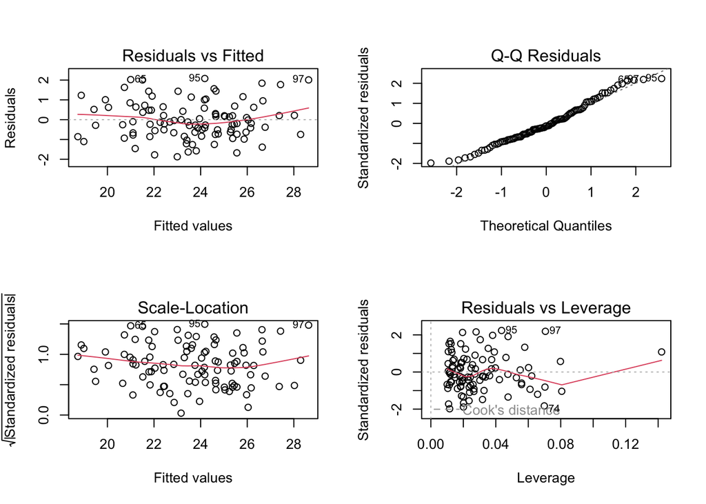

```r
# Residual analysis
par(mfrow = c(2, 2))
plot(model_multiple)
```

```r
# Check for heteroscedasticity
library(car)
ncvTest(model_multiple)
```

```
## Non-constant Variance Score Test
## Variance formula: ~ fitted.values
## Chisquare = 0.002438205, Df = 1, p = 0.96062
```

```r
# Check for multicollinearity
vif(model_multiple)
```

```
##       x1       x2
## 1.002459 1.002459
```

# Practical Applications and Demonstrations of Regression Analysis

## Introduction

This section transitions from theoretical understanding to practical application, allowing students to apply regression analysis concepts to real-world data. Through hands-on activities, we aim to deepen comprehension and enhance analytical skills.

## Engaging with Real Data: Understanding Through Action

### Constructing and Interpreting Regression Models

- **Objective**: Fit and interpret simple and multiple linear regression models.
- **Activity**:
  - Construct regression models using real data.
  - Interpret the coefficients and assess the fit of the models.

**Example: Predicting House Prices**

```r
# Sample data: House prices, square footage, and number of bedrooms
set.seed(123)
prices <- c(300000, 350000, 400000, 250000, 450000, 500000)
sqft <- c(1500, 1600, 1700, 1400, 1800, 2000)
bedrooms <- c(3, 3, 4, 2, 4, 5)

house_data <- data.frame(prices, sqft, bedrooms)

# Fit Simple Linear Regression
model_simple <- lm(prices ~ sqft, data = house_data)
summary(model_simple)
```

```
##
## Call:
## lm(formula = prices ~ sqft, data = house_data)
##
## Residuals:
##      1      2      3      4      5      6
##  -3571   3571  10714 -10714  17857 -17857
##
## Coefficients:
##               Estimate Std. Error t value Pr(>|t|)
## (Intercept) -339285.71   51908.72  -6.536 0.002831 **
## sqft            428.57      30.93  13.856 0.000157 ***
## ---
## Signif. codes:  0 '***' 0.001 '**' 0.01 '*' 0.05 '.' 0.1 ' ' 1
##
## Residual standard error: 14940 on 4 degrees of freedom
## Multiple R-squared:  0.9796, Adjusted R-squared:  0.9745
## F-statistic:   192 on 1 and 4 DF,  p-value: 0.0001573
```

```r
# Fit Multiple Linear Regression
model_multiple <- lm(prices ~ sqft + bedrooms, data = house_data)
summary(model_multiple)
```

```
##
## Call:
## lm(formula = prices ~ sqft + bedrooms, data = house_data)
##
## Residuals:
##      1      2      3      4      5      6
##  -6818   5682   6818  -7955  19318 -17045
##
## Coefficients:
##             Estimate Std. Error t value Pr(>|t|)
## (Intercept)  -289773     143493  -2.019   0.1367
## sqft             375        146   2.569   0.0826 .
## bedrooms       11364      30065   0.378   0.7306
## ---
## Signif. codes:  0 '***' 0.001 '**' 0.01 '*' 0.05 '.' 0.1 ' ' 1
##
## Residual standard error: 16850 on 3 degrees of freedom
## Multiple R-squared:  0.9805, Adjusted R-squared:  0.9675
## F-statistic:  75.5 on 2 and 3 DF,  p-value: 0.002719
```

### Residual Analysis and Model Diagnostics

- **Objective**: Validate regression models by analyzing residuals and checking assumptions.
- **Activity**:
  - Perform residual analysis.
  - Check for heteroscedasticity and multicollinearity.

**Example: Residual Analysis**

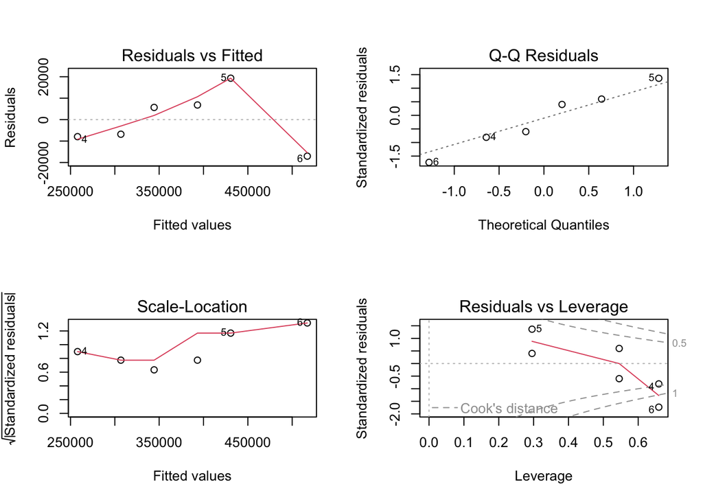

```r
# Residual analysis
par(mfrow = c(2, 2))
plot(model_multiple)
```

```r
# Check for heteroscedasticity
ncvTest(model_multiple)
```

```
## Non-constant Variance Score Test
## Variance formula: ~ fitted.values
## Chisquare = 1.522035, Df = 1, p = 0.21731
```

```r
# Check for multicollinearity
vif(model_multiple)
```

```
##     sqft bedrooms
##     17.5     17.5
```

### Model Selection and Comparison

- **Objective**: Compare different regression models using selection criteria like AIC and BIC.
- **Activity**:
  - Fit multiple models to the same data.
  - Compare models using AIC and BIC to select the best model.

**Example: Model Selection**

```r
# Model 1: Simple linear regression
model1 <- lm(prices ~ sqft, data = house_data)

# Model 2: Multiple linear regression
model2 <- lm(prices ~ sqft + bedrooms, data = house_data)

# Compare AIC and BIC
AIC(model1, model2)
```

```
##        df      AIC
## model1  3 135.9363
## model2  4 137.6572
```

```r
BIC(model1, model2)
```

```
##        df      BIC
## model1  3 135.3116
## model2  4 136.8242
```

## Summary

### Recap of Key Points

- We discussed constructing and fitting simple and multiple linear regression models.
- The importance of residual analysis and model diagnostics was highlighted.
- Model selection criteria like AIC and BIC were introduced to compare different models.

### Further Reading and Resources

- **Books**: “An Introduction to Statistical Learning” by Gareth James, Daniela Witten, Trevor Hastie, and Robert Tibshirani provides a comprehensive understanding of regression and other statistical methods.
- **Online Courses**: Platforms like Coursera and edX offer courses on regression analysis and related statistical techniques.
- **Articles**: Research articles in journals like the “Journal of Applied Statistics” provide deeper insights and case studies involving regression analysis.

Students, by now, can enhance their ability to conduct and interpret regression analyses, preparing them for professional roles that require strong statistical analysis skills.